# Lab 01

This lab serves to verify that you have set-up R correctly, install some standard packages, and to test the lab submission process. You must submit this by the first Friday of the term at noon. If you run into any difficulty, please contact me before that time.

Please run the following R code to verify that the R engine is working proerly:

```r
1 + 1
```

```
[1] 2
```

## Install packages

Now, let’s install the three core packages that we will use every class. The following code will see if a package is installed and only if it is not will it attempt to donwload it. Start with the **readr** package:

```r
if (!require("readr")) {
  install.packages("readr")
}
```

Next, we’ll download **dplyr**:

```r
if (!require("dplyr")) {
  install.packages("dplyr")
}
```

And finally, we will install **viridis** (it will also install **ggplot2**):

```r
if (!require("viridis")) {
  install.packages("viridis")
}
```

## RStudio settings

There are some default settings that will be useful to tweak before moving forward. If you don’t do this, R will save datasets between sessions. After a week or two it will start to slow down and eventually crash everything you open the application. Instead, follow these simple steps:

1. In the RStudio menu click on `Tools > Global Options...`
2. Look for the first drop-down: `Save the workspace to .RData on exit`
3. Change this first drop-down to `Never`
4. All of the check-boxes above this dropdown should be unchecked.

## Read in mammal sleep data

Now, load the libraries from above. **If this gives a warning, you need to solve the issue BEFORE continuing.**

```r
library(readr)
library(dplyr)
library(ggplot2)
library(viridis)
```

As in class, load the mammals sleep data:

```r
msleep <- read_csv("https://statsmaths.github.io/ml_data/msleep.csv")
```

Check that figures are produced correctly:

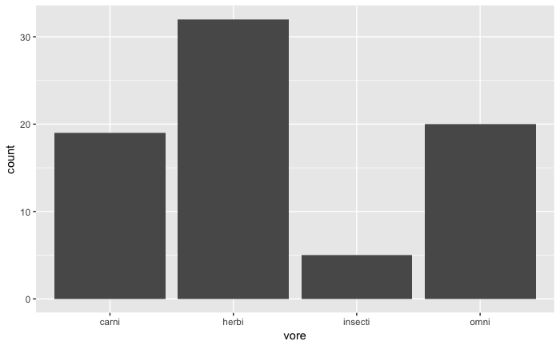

```r
qplot(vore, data = msleep)
```

We’ll fit a model and save the predictions as a new column:

```r
model <- lm(awake ~ bodywt_log, data = msleep)
msleep$awake_pred <- predict(model, msleep)
```

And finally, we create a submission data frame and save it as a csv file:

```r
submit <- select(msleep, obs_id, awake_pred)
write_csv(submit, "class01_submit.csv")
```

Now, upload this file (ends with “.Rmd”), the HTML output (ends with “.nb.html”), and the csv file to GitHub.